# Storm Data Events Analytics: Analysis of storms and other significant weather phenomena across US

Rama Tripathy

March 12, 2017

## Synopsis

In this report, we analyze the Storms data collected from National Weather Services(NWS) and other sources including media reports and try to answer these questions:  
1. Across the United States, which types of events (as indicated in the EVTYPE variable) are most harmful with respect to population health?  
2. Across the United States, which types of events have the greatest economic consequences?

## Setup options

### Software Environment

1. R version 3.0.2
2. Platform: x86_64-windows
3. Attached base packages:
- data.table package to directly read zip/.bz2/csv format
- plyr and dplyr to manipulate the data
- ggplot2 package for plots
- xtable package to produce nice tables
4. Setup local directory
5. Setup global options

```r
knitr::opts_knit$set(warn=-1) #surpress warnings
knitr::opts_knit$set(echo = TRUE)
library(knitr)
library("data.table")
library(plyr)
library(dplyr)
```

```r
library(ggplot2)
library(xtable)
# install package 'fiftystater' from github
# install.packages("devtools")
# devtools::install_github("wmurphyrd/fiftystater")
library(fiftystater)

knitr::opts_knit$set(root.dir = "E:\\Coursera\\Reproducible_Research\\Storms_Data_Analytics\\")
```

## Data Processing

### Read raw Data from web site

```r
knitr::opts_knit$set(warn=-1) #surpress warnings
url <- "https://d396qusza40orc.cloudfront.net/repdata%2Fdata%2FStormData.csv.bz2"
download.file(url,destfile="repdata-data-StormData.csv.bz2")
stormdata <- read.table("StormData.csv.bz2", header=TRUE, quote="\"", sep=",",
                        stringsAsFactors = FALSE)
```

### Check dimension and the variables and their types

```r
glimpse(stormdata)
```

```
## Observations: 902,297
## Variables: 37
## $ STATE__    (dbl) 1, 1, 1, 1, 1, 1, 1, 1, 1, 1, 1, 1, 1, 1, 1, 1, 1, ...
## $ BGN_DATE   (chr) "4/18/1950 0:00:00", "4/18/1950 0:00:00", "2/20/195...
## $ BGN_TIME   (chr) "0130", "0145", "1600", "0900", "1500", "2000", "01...
## $ TIME_ZONE  (chr) "CST", "CST", "CST", "CST", "CST", "CST", "CST", "C...
## $ COUNTY     (dbl) 97, 3, 57, 89, 43, 77, 9, 123, 125, 57, 43, 9, 73, ...
## $ COUNTYNAME (chr) "MOBILE", "BALDWIN", "FAYETTE", "MADISON", "CULLMAN...
## $ STATE      (chr) "AL", "AL", "AL", "AL", "AL", "AL", "AL", "AL", "AL...
## $ EVTYPE     (chr) "TORNADO", "TORNADO", "TORNADO", "TORNADO", "TORNAD...
## $ BGN_RANGE  (dbl) 0, 0, 0, 0, 0, 0, 0, 0, 0, 0, 0, 0, 0, 0, 0, 0, 0, ...
## $ BGN_AZI    (chr) "", "", "", "", "", "", "", "", "", "", "", "", "",...
## $ BGN_LOCATI (chr) "", "", "", "", "", "", "", "", "", "", "", "", "",...
## $ END_DATE   (chr) "", "", "", "", "", "", "", "", "", "", "", "", "",...
## $ END_TIME   (chr) "", "", "", "", "", "", "", "", "", "", "", "", "",...
```

[output cut: 24 more lines]

### Take an intial look into the storm data

```r
head(stormdata)
```

```
##   STATE__           BGN_DATE BGN_TIME TIME_ZONE COUNTY COUNTYNAME STATE
## 1       1  4/18/1950 0:00:00     0130       CST     97     MOBILE    AL
## 2       1  4/18/1950 0:00:00     0145       CST      3    BALDWIN    AL
## 3       1  2/20/1951 0:00:00     1600       CST     57    FAYETTE    AL
## 4       1   6/8/1951 0:00:00     0900       CST     89    MADISON    AL
## 5       1 11/15/1951 0:00:00     1500       CST     43    CULLMAN    AL
## 6       1 11/15/1951 0:00:00     2000       CST     77 LAUDERDALE    AL
##    EVTYPE BGN_RANGE BGN_AZI BGN_LOCATI END_DATE END_TIME COUNTY_END
## 1 TORNADO         0                                               0
## 2 TORNADO         0                                               0
## 3 TORNADO         0                                               0
## 4 TORNADO         0                                               0
## 5 TORNADO         0                                               0
## 6 TORNADO         0                                               0
##   COUNTYENDN END_RANGE END_AZI END_LOCATI LENGTH WIDTH F MAG FATALITIES
```

[output cut: 20 more lines]

### Check summary to:

- identify missing values
- minimum and maximum field values to determine possible outliers

```r
summary(stormdata)
```

```
##     STATE__       BGN_DATE           BGN_TIME          TIME_ZONE
##  Min.   : 1.0   Length:902297      Length:902297      Length:902297
##  1st Qu.:19.0   Class :character   Class :character   Class :character
##  Median :30.0   Mode  :character   Mode  :character   Mode  :character
##  Mean   :31.2
##  3rd Qu.:45.0
##  Max.   :95.0
##
##      COUNTY       COUNTYNAME           STATE              EVTYPE
##  Min.   :  0.0   Length:902297      Length:902297      Length:902297
##  1st Qu.: 31.0   Class :character   Class :character   Class :character
##  Median : 75.0   Mode  :character   Mode  :character   Mode  :character
##  Mean   :100.6
##  3rd Qu.:131.0
##  Max.   :873.0
##
##    BGN_RANGE          BGN_AZI           BGN_LOCATI
##  Min.   :   0.000   Length:902297      Length:902297
##  1st Qu.:   0.000   Class :character   Class :character
##  Median :   0.000   Mode  :character   Mode  :character
##  Mean   :   1.484
##  3rd Qu.:   1.000
##  Max.   :3749.000
##
##    END_DATE           END_TIME           COUNTY_END COUNTYENDN
##  Length:902297      Length:902297      Min.   :0    Mode:logical
##  Class :character   Class :character   1st Qu.:0    NA's:902297
##  Mode  :character   Mode  :character   Median :0
##                                        Mean   :0
##                                        3rd Qu.:0
##                                        Max.   :0
##
##    END_RANGE          END_AZI           END_LOCATI
##  Min.   :  0.0000   Length:902297      Length:902297
##  1st Qu.:  0.0000   Class :character   Class :character
##  Median :  0.0000   Mode  :character   Mode  :character
##  Mean   :  0.9862
##  3rd Qu.:  0.0000
##  Max.   :925.0000
##
```

[output cut: 33 more lines]

```
##  Min.   :-14451   Min.   :   0   Min.   :-14455   Length:902297
##  1st Qu.:  7247   1st Qu.:   0   1st Qu.:     0   Class :character
##  Median :  8707   Median :   0   Median :     0   Mode  :character
##  Mean   :  6940   Mean   :1452   Mean   :  3509
##  3rd Qu.:  9605   3rd Qu.:3549   3rd Qu.:  8735
##  Max.   : 17124   Max.   :9706   Max.   :106220
##                   NA's   :40
##      REFNUM
##  Min.   :     1
##  1st Qu.:225575
##  Median :451149
##  Mean   :451149
##  3rd Qu.:676723
##  Max.   :902297
##
```

### Identify fields to be used for our analysis

1. We will need the following fields:  
   Location - STATE, COUNTY, LATITUDE, LONGITUDE, LATITUDE_E, LONGITUDE_)  
   Event type (EVTYPE)  
   Beginning/end date and time (BGN_DATE, BGN_TIME, TIME_ZONE, END_DATE, END_TIME)  
   Health Impact - FATALITIES, INJURIES  
   Property Damage - comprised of two parts:
- a 3-significant numeric field (PROPDMG)
- a field to indicate magnitude (K = 1000, M = Million…) PROPDMGEXP  
  Corp Damage - comprised of two parts:
- a 3-significant numeric field (CROPDMG)
- a field to indicate magnitude (K = 1000, M = Million…) CROPDMGEXP

```r
stormdata <- select(stormdata, STATE, COUNTY, LATITUDE, LONGITUDE,
                    LATITUDE_E, LONGITUDE_, EVTYPE, BGN_DATE, BGN_TIME,
                    TIME_ZONE, END_DATE, END_TIME, FATALITIES, INJURIES,
                    PROPDMG, PROPDMGEXP, CROPDMG, CROPDMGEXP, REFNUM)
```

2. Transform STATE, EVTYPE to factor variables

```r
stormdata$STATE <- as.factor(stormdata$STATE)
stormdata$EVTYPE <- as.factor(stormdata$EVTYPE)
stormdata$PROPDMGEXP <- as.character(stormdata$PROPDMGEXP)
stormdata$CROPDMGEXP <- as.character(stormdata$CROPDMGEXP)
```

### Calculate actual Property/Crop Damages in thousands

1. We will convert the magnitude field to numeric value and multiply it with  
   property/crop damage field to calculate actual vale.
2. PROPDMGEXP column specifies the amount for PROPDMG in:
- Hundreds(H/0/1/2/3/4/5/6/7/8)
- Thousands(K)
- Millions(M)
- Billions(B)
- consider blank/-/+/? values as 10 for PROPDMGEXP
3. CROPDMGEXP column specifies the amount for CROPDMG in:
- Hundreds(0/1/2)
- Thousands(K)
- Millions(M)
- Billions(B)
- consider blank/-/+/? values as 10 for CROPDMGEXP
4. We will use switch function for this conversion

```r
magnitudeValue <- function(value, magnitude){
             v <- switch(magnitude,
                      H = .1, h = .1,
                      K = 1, k = 1,
                      M = 1000, m = 1000,
                      B = 1000000, b = 1000000,
                      Otherwise = .01)
             if(!is.null(v))
               value <- value*v
             else  value <- .01*value
             value
             }
```

5. Calculate property damage, crop damage and total damage  
   total economic impact= property damage + crop damage

```r
knitr::opts_knit$set(warn=-1) #surpress warnings
stormdata <- as.data.frame(stormdata %>% group_by(REFNUM) %>% mutate(PropertyDamage=magnitudeValue(PROPDMG,PROPDMGEXP)))
stormdata <- as.data.frame(stormdata %>% group_by(REFNUM) %>% mutate(CropDamage=magnitudeValue(CROPDMG,CROPDMGEXP)))
stormdata$TotalDamage <- stormdata$CropDamage + stormdata$PropertyDamage
```

### Calculate total health impact

total health impact= fatalities + injuries

```r
stormdata$TotalHealthImpact <- stormdata$FATALITIES + stormdata$INJURIES
```

### Take alook into the new fields in storm data now

```r
head(select(stormdata, FATALITIES,INJURIES,TotalHealthImpact,
             PropertyDamage,CropDamage,TotalDamage))
```

```
##   FATALITIES INJURIES TotalHealthImpact PropertyDamage CropDamage
## 1          0       15                15           25.0          0
## 2          0        0                 0            2.5          0
## 3          0        2                 2           25.0          0
## 4          0        2                 2            2.5          0
## 5          0        2                 2            2.5          0
## 6          0        6                 6            2.5          0
##   TotalDamage
## 1        25.0
## 2         2.5
## 3        25.0
## 4         2.5
## 5         2.5
## 6         2.5
```

Free up some memory

```r
gc(verbose = FALSE)
```

```
##            used  (Mb) gc trigger  (Mb) max used  (Mb)
## Ncells   670589  35.9    2564361 137.0  3205452 171.2
## Vcells 21703251 165.6   62018092 473.2 96856230 739.0
```

## Results

### Which types of events are most harmful to population health?

Aggregate and find most harmful event type to health

```r
knitr::opts_knit$set(cache = TRUE)
# Number of injuries by eventtype
injuriesbyev <- aggregate(INJURIES ~ EVTYPE, data = stormdata, FUN = sum)
#
# Number of fatalities by event type
fatalitiesbyev <- aggregate(FATALITIES ~ EVTYPE, data = stormdata, FUN = sum)
#
# Total Health Impact by event type
hibyev <- merge(injuriesbyev, fatalitiesbyev) # merge by event tye
# Calculate the total health loss by eventtype
hibyev <- mutate(hibyev, totalbyev = INJURIES + FATALITIES ) %>% setorder(-totalbyev)
rm(injuriesbyev)
rm(fatalitiesbyev)
```

1. Most harmful events to population health are:

```r
library(xtable)
kable(head(hibyev,20))
```

[output not shown]

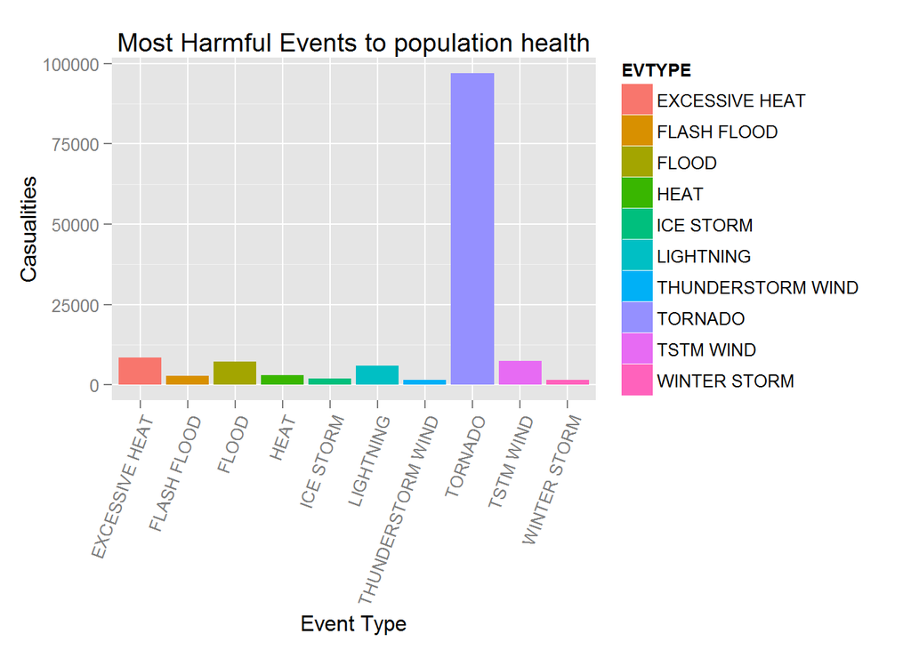

```r
library(ggplot2)
ggplot(hibyev[1:10,], aes(x=EVTYPE, y = totalbyev, fill = EVTYPE)) +
  geom_bar(stat = "identity") +
  theme(axis.text.x = element_text(angle = 70, hjust = 1)) +
  xlab("Event Type") +
  ylab("Casualities") +
  ggtitle("Most Harmful Events to population health")
```

### Which types of events have the greatest economic consequences across US? Aggregate and find most harmful event type to economy

```r
knitr::opts_knit$set(cache = TRUE)
# Property damage by eventtype
pdmgbyev <- aggregate(PROPDMG ~ EVTYPE, data = stormdata, FUN = sum)
# Number of fatalities by event type
cdmgbyev <- aggregate(CROPDMG ~ EVTYPE, data = stormdata, FUN = sum)
tdmgbyev <- merge(pdmgbyev, cdmgbyev) # merge by event tye
# Calculate the total damage by eventtype
tdmgbyev <- mutate(tdmgbyev, TotalDamage = PROPDMG + CROPDMG ) %>% setorder(-TotalDamage)
rm(pdmgbyev)
rm(cdmgbyev)
```

```r
library(xtable)
kable(head(tdmgbyev,20))
```

[output not shown]

[figure not shown]

```r
library(ggplot2)
ggplot(tdmgbyev[1:10,], aes(x=EVTYPE, y = TotalDamage, fill = EVTYPE)) +
  geom_bar(stat = "identity") +
  theme(axis.text.x = element_text(angle = 70, hjust = 1)) +
  ylab("Total Damage in thousand") +
  xlab("Event Type") +
  ggtitle("Most Economic Harmful Events across US")
```

### Analysis of Storm Even Impact by each State in US  
1. Aggregate and find most harmful to health impact by state

```r
knitr::opts_knit$set(cache = TRUE)
# Number of injuries by eventtype by stste
injuriesbyst <- aggregate(INJURIES ~ EVTYPE + STATE, data = stormdata,
                          FUN = sum)
#
# Number of fatalities by event type
fatalitiesbyst <- aggregate(FATALITIES ~ EVTYPE + STATE, data = stormdata,
                            FUN = sum)
#
# Total Health Impact by event type
hibyevst <- merge(injuriesbyst, fatalitiesbyst) #merge by event type and state
# Calculate the total health loss by eventtype
hibyevst <- mutate(hibyevst, totalbyst = INJURIES + FATALITIES ) %>% setorder(-totalbyst)
rm(injuriesbyst)
rm(fatalitiesbyst)
```

2. Aggregate and find most harmful event type to economy by state

```r
knitr::opts_knit$set(cache = TRUE)
# Property damage by eventtype
pdmgbyst <- aggregate(PROPDMG ~ EVTYPE + STATE, data = stormdata, FUN = sum)
# Number of fatalities by event type
cdmgbyst <- aggregate(CROPDMG ~ EVTYPE + STATE, data = stormdata, FUN = sum)
tdmgbyevst <- merge(pdmgbyst, cdmgbyst) # merge by event type and state
# Calculate the total damage by eventtype
tdmgbyevst <- mutate(tdmgbyevst, TotalDamage = PROPDMG + CROPDMG ) %>% setorder(-TotalDamage)
rm(pdmgbyst)
rm(cdmgbyst)
```